# Risk Factor Analysis

## Outcome Variable

**Outcome Variable:** pers_wast

## Predictor Variables

**Intervention Variable:** parity

**Adjustment Set:**

- arm
- W_mage
- meducyrs
- feducyrs
- hhwealth_quart
- W_mhtcm
- W_mwtkg
- W_mbmi
- vagbrth
- W_nrooms
- impsan
- delta_W_mage
- delta_meducyrs
- delta_feducyrs
- delta_hhwealth_quart
- delta_W_mhtcm
- delta_W_mwtkg
- delta_W_mbmi
- delta_vagbrth
- delta_W_nrooms
- delta_impsan

## Stratifying Variables

The analysis was stratified on these variable(s):

- agecat
- studyid
- country

## Data Summary

| agecat | studyid | country | parity | pers_wast | n_cell | n |
| --- | --- | --- | --- | --- | --- | --- |
| 0-24 months | COHORTS | GUATEMALA | 1 | 0 | 142 | 1053 |
| 0-24 months | COHORTS | GUATEMALA | 1 | 1 | 4 | 1053 |
| 0-24 months | COHORTS | GUATEMALA | 2 | 0 | 144 | 1053 |
| 0-24 months | COHORTS | GUATEMALA | 2 | 1 | 3 | 1053 |
| 0-24 months | COHORTS | GUATEMALA | 3+ | 0 | 731 | 1053 |
| 0-24 months | COHORTS | GUATEMALA | 3+ | 1 | 29 | 1053 |
| 0-24 months | COHORTS | INDIA | 1 | 0 | 550 | 3595 |
| 0-24 months | COHORTS | INDIA | 1 | 1 | 46 | 3595 |
| 0-24 months | COHORTS | INDIA | 2 | 0 | 825 | 3595 |
| 0-24 months | COHORTS | INDIA | 2 | 1 | 73 | 3595 |
| 0-24 months | COHORTS | INDIA | 3+ | 0 | 1853 | 3595 |
| 0-24 months | COHORTS | INDIA | 3+ | 1 | 248 | 3595 |
| 0-24 months | COHORTS | PHILIPPINES | 1 | 0 | 583 | 2811 |
| 0-24 months | COHORTS | PHILIPPINES | 1 | 1 | 24 | 2811 |
| 0-24 months | COHORTS | PHILIPPINES | 2 | 0 | 608 | 2811 |
| 0-24 months | COHORTS | PHILIPPINES | 2 | 1 | 19 | 2811 |
| 0-24 months | COHORTS | PHILIPPINES | 3+ | 0 | 1476 | 2811 |
| 0-24 months | COHORTS | PHILIPPINES | 3+ | 1 | 101 | 2811 |
| 0-24 months | GMS-Nepal | NEPAL | 1 | 0 | 150 | 597 |
| 0-24 months | GMS-Nepal | NEPAL | 1 | 1 | 19 | 597 |
| 0-24 months | GMS-Nepal | NEPAL | 2 | 0 | 130 | 597 |
| 0-24 months | GMS-Nepal | NEPAL | 2 | 1 | 25 | 597 |
| 0-24 months | GMS-Nepal | NEPAL | 3+ | 0 | 237 | 597 |
| 0-24 months | GMS-Nepal | NEPAL | 3+ | 1 | 36 | 597 |
| 0-24 months | JiVitA-3 | BANGLADESH | 1 | 0 | 5444 | 15803 |
| 0-24 months | JiVitA-3 | BANGLADESH | 1 | 1 | 365 | 15803 |
| 0-24 months | JiVitA-3 | BANGLADESH | 2 | 0 | 5185 | 15803 |
| 0-24 months | JiVitA-3 | BANGLADESH | 2 | 1 | 256 | 15803 |
| 0-24 months | JiVitA-3 | BANGLADESH | 3+ | 0 | 4276 | 15803 |
| 0-24 months | JiVitA-3 | BANGLADESH | 3+ | 1 | 277 | 15803 |
| 0-24 months | Keneba | GAMBIA | 1 | 0 | 218 | 1853 |
| 0-24 months | Keneba | GAMBIA | 1 | 1 | 11 | 1853 |
| 0-24 months | Keneba | GAMBIA | 2 | 0 | 190 | 1853 |
| 0-24 months | Keneba | GAMBIA | 2 | 1 | 10 | 1853 |
| 0-24 months | Keneba | GAMBIA | 3+ | 0 | 1342 | 1853 |
| 0-24 months | Keneba | GAMBIA | 3+ | 1 | 82 | 1853 |
| 0-24 months | PROVIDE | BANGLADESH | 1 | 0 | 238 | 641 |
| 0-24 months | PROVIDE | BANGLADESH | 1 | 1 | 4 | 641 |
| 0-24 months | PROVIDE | BANGLADESH | 2 | 0 | 223 | 641 |
| 0-24 months | PROVIDE | BANGLADESH | 2 | 1 | 4 | 641 |
| 0-24 months | PROVIDE | BANGLADESH | 3+ | 0 | 165 | 641 |
| 0-24 months | PROVIDE | BANGLADESH | 3+ | 1 | 7 | 641 |
| 0-24 months | SAS-CompFeed | INDIA | 1 | 0 | 378 | 1366 |
| 0-24 months | SAS-CompFeed | INDIA | 1 | 1 | 30 | 1366 |
| 0-24 months | SAS-CompFeed | INDIA | 2 | 0 | 291 | 1366 |
| 0-24 months | SAS-CompFeed | INDIA | 2 | 1 | 27 | 1366 |
| 0-24 months | SAS-CompFeed | INDIA | 3+ | 0 | 583 | 1366 |
| 0-24 months | SAS-CompFeed | INDIA | 3+ | 1 | 57 | 1366 |
| 0-24 months | SAS-FoodSuppl | INDIA | 1 | 0 | 1 | 375 |
| 0-24 months | SAS-FoodSuppl | INDIA | 1 | 1 | 1 | 375 |
| 0-24 months | SAS-FoodSuppl | INDIA | 2 | 0 | 62 | 375 |
| 0-24 months | SAS-FoodSuppl | INDIA | 2 | 1 | 7 | 375 |
| 0-24 months | SAS-FoodSuppl | INDIA | 3+ | 0 | 247 | 375 |
| 0-24 months | SAS-FoodSuppl | INDIA | 3+ | 1 | 57 | 375 |
| 0-24 months | TanzaniaChild2 | TANZANIA, UNITED REPUBLIC OF | 1 | 0 | 710 | 2132 |
| 0-24 months | TanzaniaChild2 | TANZANIA, UNITED REPUBLIC OF | 1 | 1 | 18 | 2132 |
| 0-24 months | TanzaniaChild2 | TANZANIA, UNITED REPUBLIC OF | 2 | 0 | 683 | 2132 |
| 0-24 months | TanzaniaChild2 | TANZANIA, UNITED REPUBLIC OF | 2 | 1 | 20 | 2132 |
| 0-24 months | TanzaniaChild2 | TANZANIA, UNITED REPUBLIC OF | 3+ | 0 | 682 | 2132 |
| 0-24 months | TanzaniaChild2 | TANZANIA, UNITED REPUBLIC OF | 3+ | 1 | 19 | 2132 |
| 0-24 months | ZVITAMBO | ZIMBABWE | 1 | 0 | 3741 | 9526 |
| 0-24 months | ZVITAMBO | ZIMBABWE | 1 | 1 | 63 | 9526 |
| 0-24 months | ZVITAMBO | ZIMBABWE | 2 | 0 | 2873 | 9526 |
| 0-24 months | ZVITAMBO | ZIMBABWE | 2 | 1 | 51 | 9526 |
| 0-24 months | ZVITAMBO | ZIMBABWE | 3+ | 0 | 2744 | 9526 |
| 0-24 months | ZVITAMBO | ZIMBABWE | 3+ | 1 | 54 | 9526 |

The following strata were considered:

- agecat: 0-24 months, studyid: COHORTS, country: GUATEMALA
- agecat: 0-24 months, studyid: COHORTS, country: INDIA
- agecat: 0-24 months, studyid: COHORTS, country: PHILIPPINES
- agecat: 0-24 months, studyid: GMS-Nepal, country: NEPAL
- agecat: 0-24 months, studyid: JiVitA-3, country: BANGLADESH
- agecat: 0-24 months, studyid: Keneba, country: GAMBIA
- agecat: 0-24 months, studyid: PROVIDE, country: BANGLADESH
- agecat: 0-24 months, studyid: SAS-CompFeed, country: INDIA
- agecat: 0-24 months, studyid: SAS-FoodSuppl, country: INDIA
- agecat: 0-24 months, studyid: TanzaniaChild2, country: TANZANIA, UNITED REPUBLIC OF
- agecat: 0-24 months, studyid: ZVITAMBO, country: ZIMBABWE

### Dropped Strata

Some strata were dropped due to rare outcomes:

- agecat: 0-24 months, studyid: COHORTS, country: GUATEMALA
- agecat: 0-24 months, studyid: PROVIDE, country: BANGLADESH
- agecat: 0-24 months, studyid: SAS-FoodSuppl, country: INDIA

## Methods Detail

We're interested in the causal parameters $E[Y_a]$ for all values of $a \in \mathcal{A}$. These parameters represent the mean outcome if, possibly contrary to fact, we intervened to set all units to have $A=a$. Under the randomization and positivity assumptions, these are identified by the statistical parameters $\psi_a=E_W[E_{Y|A,W}(Y|A=a,W)]$. In addition, we're interested in the mean of $Y$, $E[Y]$ under no intervention (the observed mean). We will estimate these parameters by using SuperLearner to fit the relevant likelihood factors -- $E_{Y|A,W}(Y|A=a,W)$ and $p(A=a|W)$, and then updating our likelihood fit using a joint TMLE.

For unadjusted analyses ($W=\{\}$), initial likelihoods were estimated using Lrnr_glm to estimate the simple $E(Y|A)$ and Lrnr_mean to estimate $p(A)$. For adjusted analyses, a small library containing Lrnr_glmnet, Lrnr_xgboost, and Lrnr_mean was used.

Having estimated these parameters, we will then use the delta method to estimate relative risks and attributable risks relative to a prespecified baseline level of $A$.

# Results Detail

## Results Plots

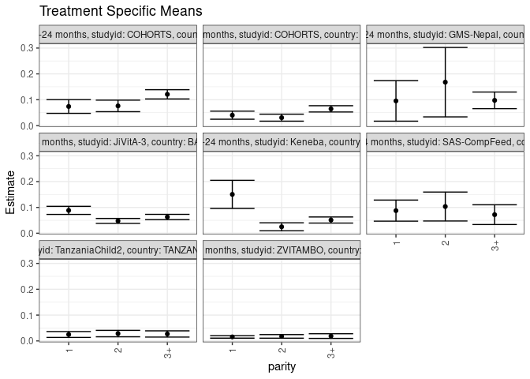

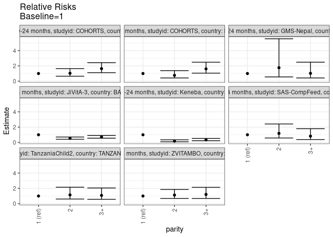

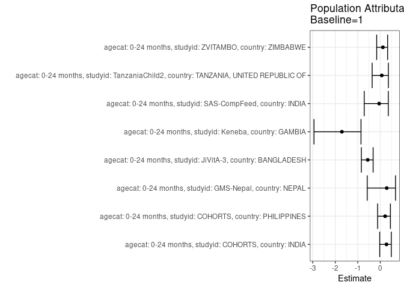

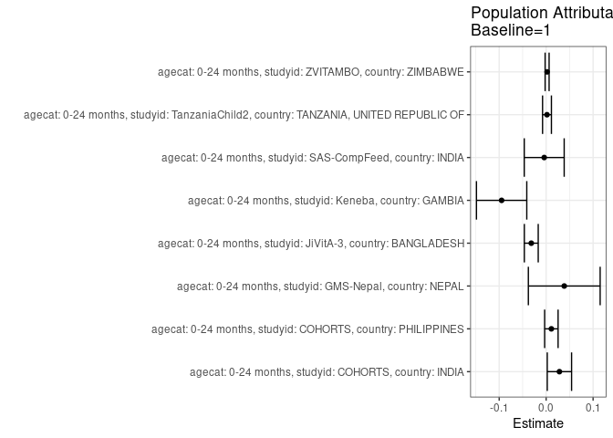

## Results Table

### Parameter: TSM

| agecat | studyid | country | intervention_level | baseline_level | estimate | ci_lower | ci_upper |
| --- | --- | --- | --- | --- | --- | --- | --- |
| 0-24 months | COHORTS | INDIA | 1 | NA | 0.0737972 | 0.0471704 | 0.1004240 |
| 0-24 months | COHORTS | INDIA | 2 | NA | 0.0760651 | 0.0536644 | 0.0984657 |
| 0-24 months | COHORTS | INDIA | 3+ | NA | 0.1208921 | 0.1029511 | 0.1388331 |
| 0-24 months | COHORTS | PHILIPPINES | 1 | NA | 0.0401065 | 0.0244958 | 0.0557173 |
| 0-24 months | COHORTS | PHILIPPINES | 2 | NA | 0.0305080 | 0.0169497 | 0.0440663 |
| 0-24 months | COHORTS | PHILIPPINES | 3+ | NA | 0.0646332 | 0.0525160 | 0.0767505 |
| 0-24 months | GMS-Nepal | NEPAL | 1 | NA | 0.0954105 | 0.0169443 | 0.1738768 |
| 0-24 months | GMS-Nepal | NEPAL | 2 | NA | 0.1679897 | 0.0336163 | 0.3023630 |
| 0-24 months | GMS-Nepal | NEPAL | 3+ | NA | 0.0975210 | 0.0653198 | 0.1297222 |
| 0-24 months | JiVitA-3 | BANGLADESH | 1 | NA | 0.0884783 | 0.0728199 | 0.1041368 |
| 0-24 months | JiVitA-3 | BANGLADESH | 2 | NA | 0.0477672 | 0.0382660 | 0.0572685 |
| 0-24 months | JiVitA-3 | BANGLADESH | 3+ | NA | 0.0629076 | 0.0527693 | 0.0730459 |
| 0-24 months | Keneba | GAMBIA | 1 | NA | 0.1504128 | 0.0959542 | 0.2048715 |
| 0-24 months | Keneba | GAMBIA | 2 | NA | 0.0249605 | 0.0095112 | 0.0404097 |
| 0-24 months | Keneba | GAMBIA | 3+ | NA | 0.0511852 | 0.0394346 | 0.0629357 |
| 0-24 months | SAS-CompFeed | INDIA | 1 | NA | 0.0875464 | 0.0467227 | 0.1283702 |
| 0-24 months | SAS-CompFeed | INDIA | 2 | NA | 0.1034097 | 0.0473879 | 0.1594314 |
| 0-24 months | SAS-CompFeed | INDIA | 3+ | NA | 0.0719805 | 0.0336925 | 0.1102684 |
| 0-24 months | TanzaniaChild2 | TANZANIA, UNITED REPUBLIC OF | 1 | NA | 0.0249177 | 0.0135369 | 0.0362985 |
| 0-24 months | TanzaniaChild2 | TANZANIA, UNITED REPUBLIC OF | 2 | NA | 0.0284888 | 0.0160637 | 0.0409140 |
| 0-24 months | TanzaniaChild2 | TANZANIA, UNITED REPUBLIC OF | 3+ | NA | 0.0269976 | 0.0148906 | 0.0391046 |
| 0-24 months | ZVITAMBO | ZIMBABWE | 1 | NA | 0.0155769 | 0.0107518 | 0.0204021 |
| 0-24 months | ZVITAMBO | ZIMBABWE | 2 | NA | 0.0175732 | 0.0106314 | 0.0245149 |
| 0-24 months | ZVITAMBO | ZIMBABWE | 3+ | NA | 0.0187834 | 0.0097289 | 0.0278379 |

### Parameter: E(Y)

| agecat | studyid | country | intervention_level | baseline_level | estimate | ci_lower | ci_upper |
| --- | --- | --- | --- | --- | --- | --- | --- |
| 0-24 months | COHORTS | INDIA | NA | NA | 0.1020862 | 0.0921879 | 0.1119845 |
| 0-24 months | COHORTS | PHILIPPINES | NA | NA | 0.0512273 | 0.0430760 | 0.0593786 |
| 0-24 months | GMS-Nepal | NEPAL | NA | NA | 0.1340034 | 0.1066544 | 0.1613523 |
| 0-24 months | JiVitA-3 | BANGLADESH | NA | NA | 0.0568247 | 0.0527145 | 0.0609348 |
| 0-24 months | Keneba | GAMBIA | NA | NA | 0.0555855 | 0.0451506 | 0.0660205 |
| 0-24 months | SAS-CompFeed | INDIA | NA | NA | 0.0834553 | 0.0601989 | 0.1067118 |
| 0-24 months | TanzaniaChild2 | TANZANIA, UNITED REPUBLIC OF | NA | NA | 0.0267355 | 0.0198866 | 0.0335843 |
| 0-24 months | ZVITAMBO | ZIMBABWE | NA | NA | 0.0176359 | 0.0149926 | 0.0202793 |

### Parameter: RR

| agecat | studyid | country | intervention_level | baseline_level | estimate | ci_lower | ci_upper |
| --- | --- | --- | --- | --- | --- | --- | --- |
| 0-24 months | COHORTS | INDIA | 1 | 1 | 1.0000000 | 1.0000000 | 1.0000000 |
| 0-24 months | COHORTS | INDIA | 2 | 1 | 1.0307308 | 0.6471205 | 1.6417435 |
| 0-24 months | COHORTS | INDIA | 3+ | 1 | 1.6381656 | 1.1092105 | 2.4193662 |
| 0-24 months | COHORTS | PHILIPPINES | 1 | 1 | 1.0000000 | 1.0000000 | 1.0000000 |
| 0-24 months | COHORTS | PHILIPPINES | 2 | 1 | 0.7606732 | 0.4213771 | 1.3731735 |
| 0-24 months | COHORTS | PHILIPPINES | 3+ | 1 | 1.6115382 | 1.0466711 | 2.4812526 |
| 0-24 months | GMS-Nepal | NEPAL | 1 | 1 | 1.0000000 | 1.0000000 | 1.0000000 |
| 0-24 months | GMS-Nepal | NEPAL | 2 | 1 | 1.7607032 | 0.5590116 | 5.5456369 |
| 0-24 months | GMS-Nepal | NEPAL | 3+ | 1 | 1.0221200 | 0.4205439 | 2.4842340 |
| 0-24 months | JiVitA-3 | BANGLADESH | 1 | 1 | 1.0000000 | 1.0000000 | 1.0000000 |
| 0-24 months | JiVitA-3 | BANGLADESH | 2 | 1 | 0.5398749 | 0.4127948 | 0.7060770 |
| 0-24 months | JiVitA-3 | BANGLADESH | 3+ | 1 | 0.7109943 | 0.5575817 | 0.9066168 |
| 0-24 months | Keneba | GAMBIA | 1 | 1 | 1.0000000 | 1.0000000 | 1.0000000 |
| 0-24 months | Keneba | GAMBIA | 2 | 1 | 0.1659463 | 0.0808917 | 0.3404326 |
| 0-24 months | Keneba | GAMBIA | 3+ | 1 | 0.3402978 | 0.2217962 | 0.5221125 |
| 0-24 months | SAS-CompFeed | INDIA | 1 | 1 | 1.0000000 | 1.0000000 | 1.0000000 |
| 0-24 months | SAS-CompFeed | INDIA | 2 | 1 | 1.1811979 | 0.5782563 | 2.4128201 |
| 0-24 months | SAS-CompFeed | INDIA | 3+ | 1 | 0.8221979 | 0.3757705 | 1.7989955 |
| 0-24 months | TanzaniaChild2 | TANZANIA, UNITED REPUBLIC OF | 1 | 1 | 1.0000000 | 1.0000000 | 1.0000000 |
| 0-24 months | TanzaniaChild2 | TANZANIA, UNITED REPUBLIC OF | 2 | 1 | 1.1433174 | 0.6079564 | 2.1501126 |
| 0-24 months | TanzaniaChild2 | TANZANIA, UNITED REPUBLIC OF | 3+ | 1 | 1.0834712 | 0.5712628 | 2.0549386 |
| 0-24 months | ZVITAMBO | ZIMBABWE | 1 | 1 | 1.0000000 | 1.0000000 | 1.0000000 |
| 0-24 months | ZVITAMBO | ZIMBABWE | 2 | 1 | 1.1281532 | 0.6829189 | 1.8636614 |
| 0-24 months | ZVITAMBO | ZIMBABWE | 3+ | 1 | 1.2058470 | 0.6799471 | 2.1385000 |

### Parameter: PAR

| agecat | studyid | country | intervention_level | baseline_level | estimate | ci_lower | ci_upper |
| --- | --- | --- | --- | --- | --- | --- | --- |
| 0-24 months | COHORTS | INDIA | 1 | NA | 0.0282890 | 0.0023899 | 0.0541881 |
| 0-24 months | COHORTS | PHILIPPINES | 1 | NA | 0.0111208 | -0.0032154 | 0.0254569 |
| 0-24 months | GMS-Nepal | NEPAL | 1 | NA | 0.0385928 | -0.0378603 | 0.1150459 |
| 0-24 months | JiVitA-3 | BANGLADESH | 1 | NA | -0.0316537 | -0.0464409 | -0.0168664 |
| 0-24 months | Keneba | GAMBIA | 1 | NA | -0.0948273 | -0.1484199 | -0.0412347 |
| 0-24 months | SAS-CompFeed | INDIA | 1 | NA | -0.0040911 | -0.0466178 | 0.0384356 |
| 0-24 months | TanzaniaChild2 | TANZANIA, UNITED REPUBLIC OF | 1 | NA | 0.0018178 | -0.0076145 | 0.0112501 |
| 0-24 months | ZVITAMBO | ZIMBABWE | 1 | NA | 0.0020590 | -0.0021956 | 0.0063136 |

### Parameter: PAF

| agecat | studyid | country | intervention_level | baseline_level | estimate | ci_lower | ci_upper |
| --- | --- | --- | --- | --- | --- | --- | --- |
| 0-24 months | COHORTS | INDIA | 1 | NA | 0.2771089 | -0.0243737 | 0.4898624 |
| 0-24 months | COHORTS | PHILIPPINES | 1 | NA | 0.2170868 | -0.1163826 | 0.4509471 |
| 0-24 months | GMS-Nepal | NEPAL | 1 | NA | 0.2879988 | -0.5797433 | 0.6790961 |
| 0-24 months | JiVitA-3 | BANGLADESH | 1 | NA | -0.5570415 | -0.8401910 | -0.3174602 |
| 0-24 months | Keneba | GAMBIA | 1 | NA | -1.7059708 | -2.9449668 | -0.8561063 |
| 0-24 months | SAS-CompFeed | INDIA | 1 | NA | -0.0490212 | -0.7130352 | 0.3576049 |
| 0-24 months | TanzaniaChild2 | TANZANIA, UNITED REPUBLIC OF | 1 | NA | 0.0679907 | -0.3602491 | 0.3614101 |
| 0-24 months | ZVITAMBO | ZIMBABWE | 1 | NA | 0.1167500 | -0.1596413 | 0.3272656 |